# Data 621 Homework 1: Moneyball

## 4.2 Pitching only model

Combine all pitching variables.

```
##
## Call:
## lm(formula = TARGET_WINS ~ TEAM_PITCHING_H + TEAM_PITCHING_HR,
##     data = train)
##
## Residuals:
##     Min      1Q  Median      3Q     Max
## -68.379  -9.340   0.787   9.917  67.847
##
## Coefficients:
##                   Estimate Std. Error t value Pr(>|t|)
## (Intercept)      52.476611   2.691696  19.496  < 2e-16 ***
## TEAM_PITCHING_H   0.015148   0.001626   9.319  < 2e-16 ***
## TEAM_PITCHING_HR  0.045438   0.005863   7.750 1.51e-14 ***
## ---
## Signif. codes:  0 '***' 0.001 '**' 0.01 '*' 0.05 '.' 0.1 ' ' 1
##
## Residual standard error: 15.2 on 1817 degrees of freedom
## Multiple R-squared:  0.06883,    Adjusted R-squared:  0.06781
## F-statistic: 67.16 on 2 and 1817 DF,  p-value: < 2.2e-16
```

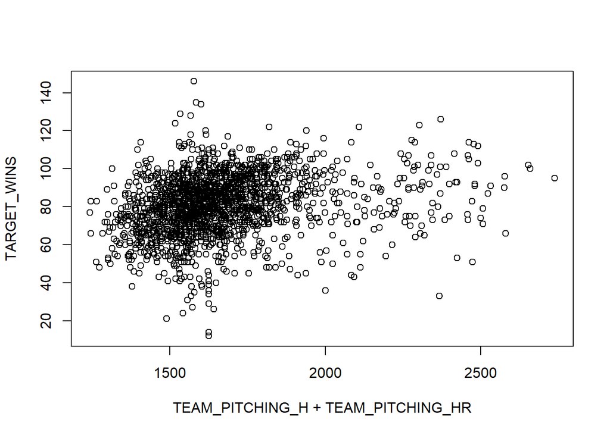

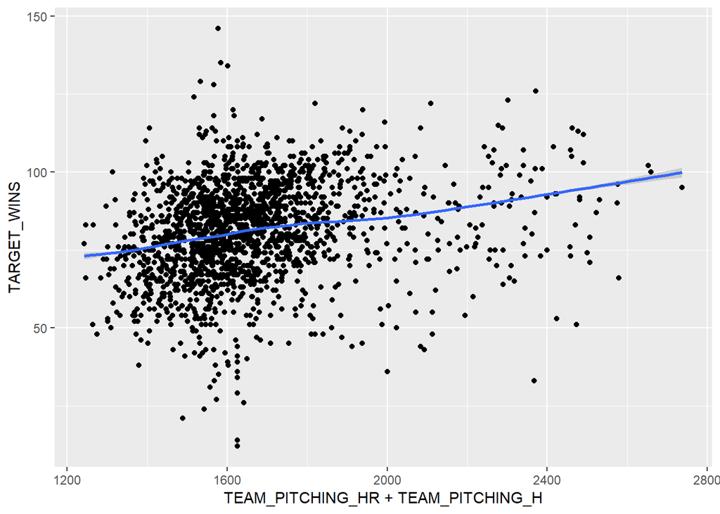

[figure not shown]

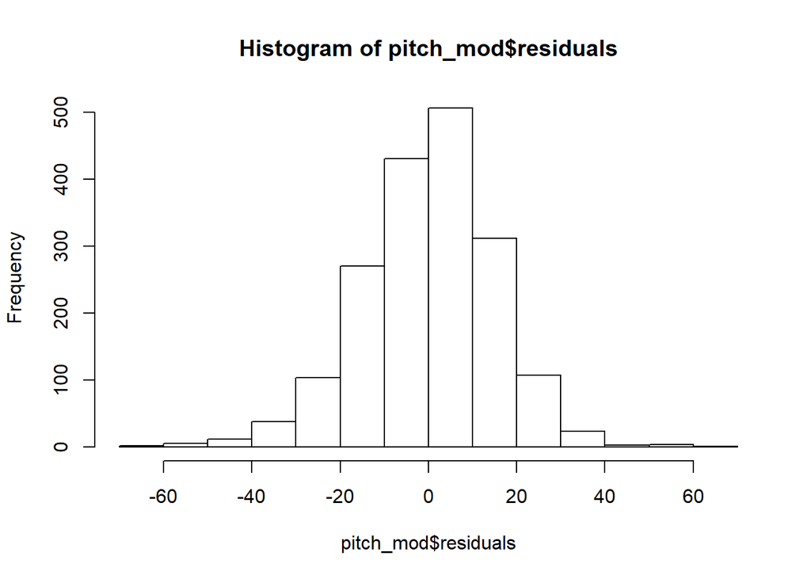

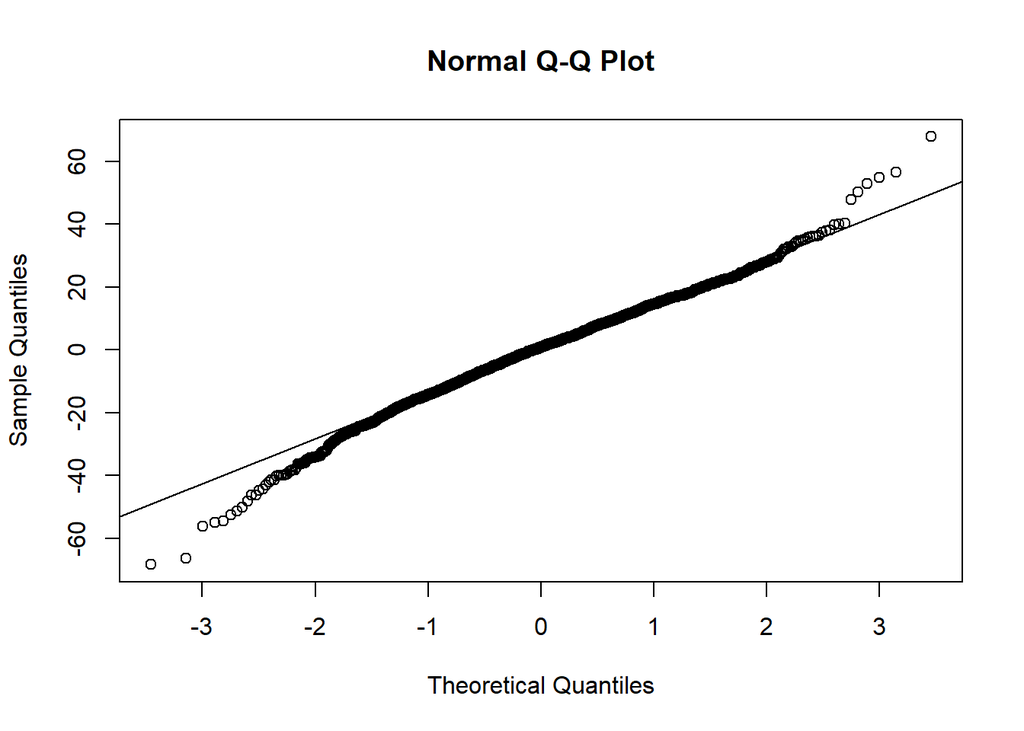

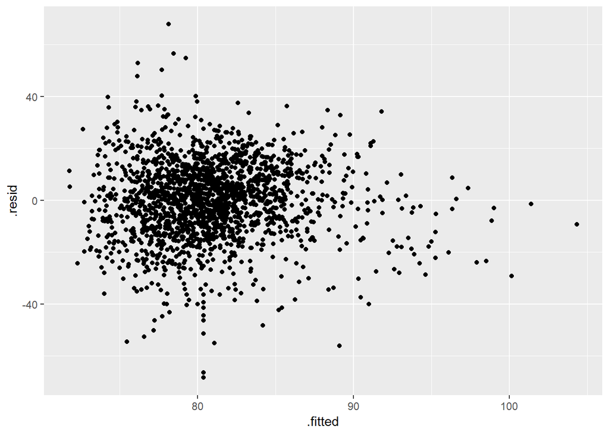

```
##
## Call:
## lm(formula = TARGET_WINS ~ HITS_NOHR)
##
## Residuals:
##     Min      1Q  Median      3Q     Max
## -67.111  -8.461   0.808  10.497  42.679
##
## Coefficients:
##             Estimate Std. Error t value Pr(>|t|)
## (Intercept) 37.86903    3.00594   12.60   <2e-16 ***
## HITS_NOHR    0.03144    0.00218   14.42   <2e-16 ***
## ---
## Signif. codes:  0 '***' 0.001 '**' 0.01 '*' 0.05 '.' 0.1 ' ' 1
##
## Residual standard error: 14.92 on 1818 degrees of freedom
## Multiple R-squared:  0.1027, Adjusted R-squared:  0.1022
## F-statistic:   208 on 1 and 1818 DF,  p-value: < 2.2e-16
```

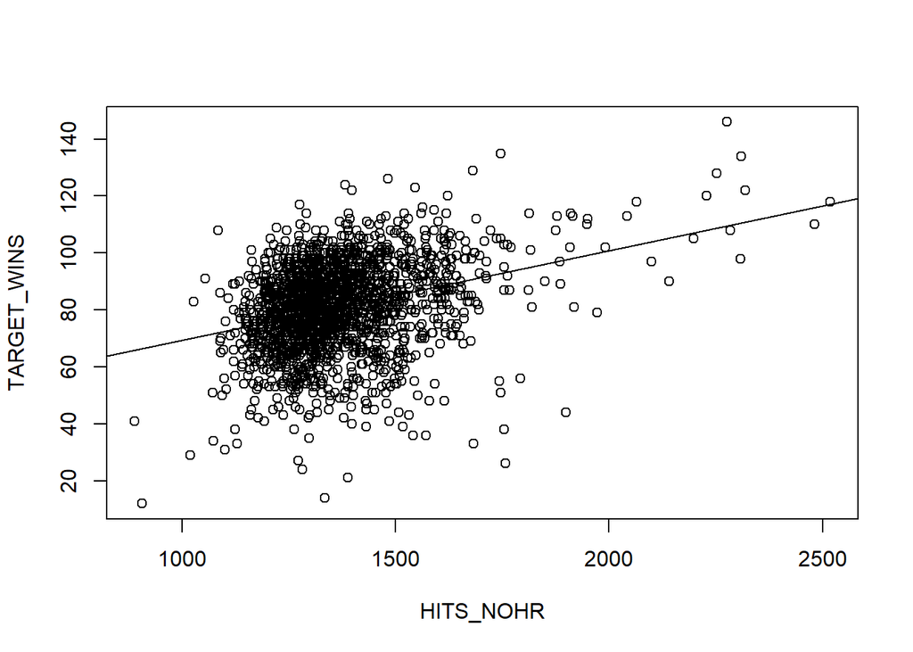

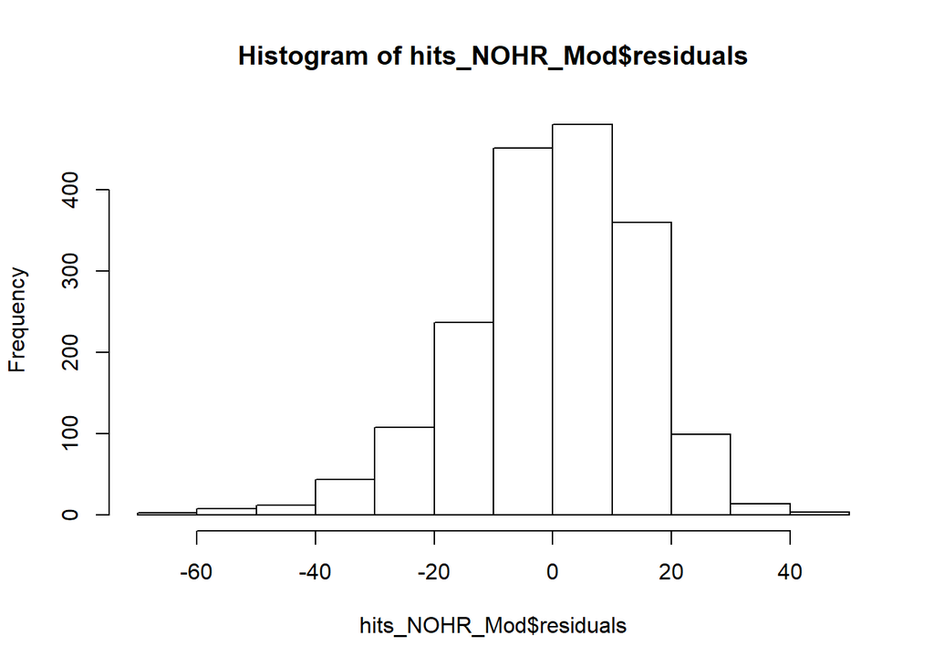

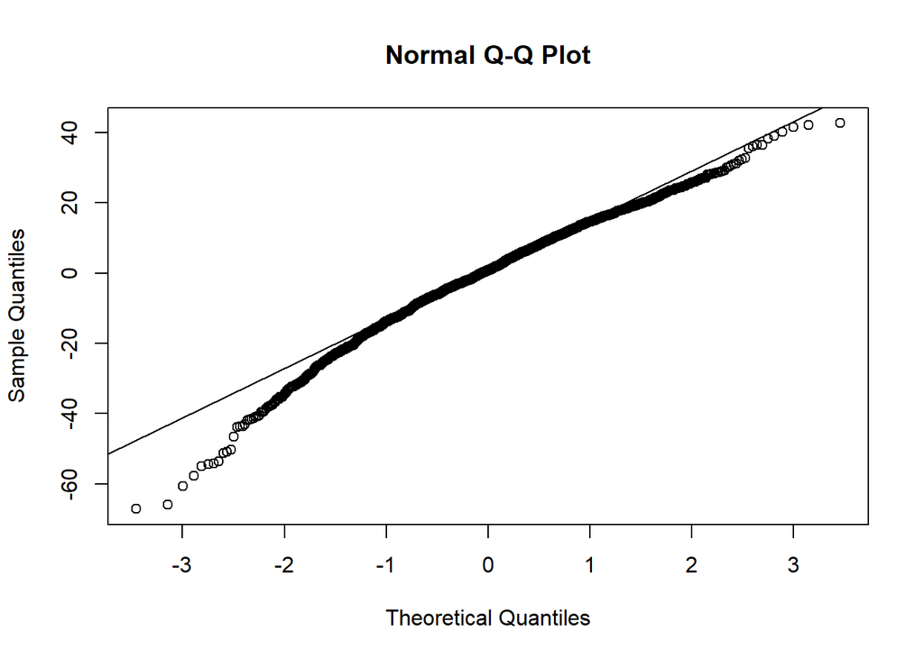

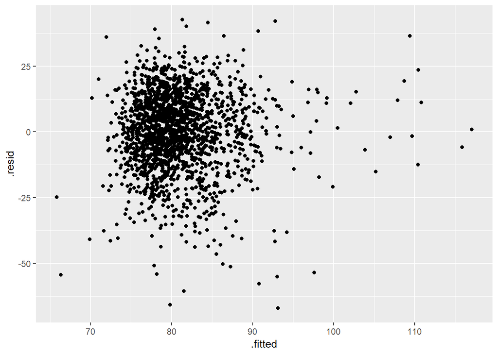

## 4.3 Model with Hits without Home Runs, BB’s and Errors

```
##
## Call:
## lm(formula = TARGET_WINS ~ TEAM_BATTING_H + TEAM_BATTING_BB +
##     TEAM_FIELDING_E, data = train)
##
## Residuals:
##     Min      1Q  Median      3Q     Max
## -51.767  -8.959   0.003   9.071  50.788
##
## Coefficients:
##                  Estimate Std. Error t value Pr(>|t|)
## (Intercept)      4.277272   3.639218   1.175 0.240018
## TEAM_BATTING_H   0.050269   0.002305  21.813  < 2e-16 ***
## TEAM_BATTING_BB  0.012509   0.003507   3.567 0.000371 ***
## TEAM_FIELDING_E -0.014193   0.002022  -7.018 3.17e-12 ***
## ---
## Signif. codes:  0 '***' 0.001 '**' 0.01 '*' 0.05 '.' 0.1 ' ' 1
##
## Residual standard error: 13.77 on 1816 degrees of freedom
## Multiple R-squared:  0.237,  Adjusted R-squared:  0.2357
## F-statistic:   188 on 3 and 1816 DF,  p-value: < 2.2e-16
```

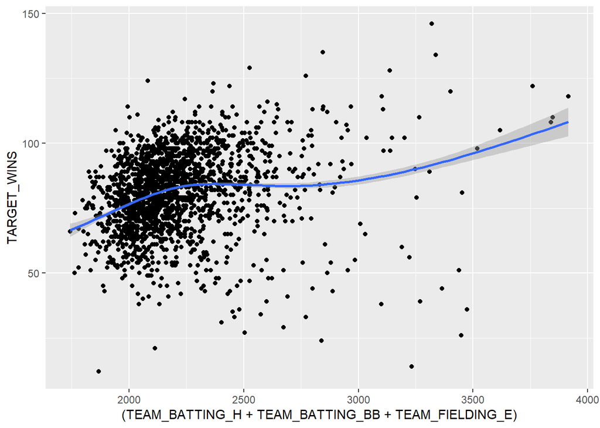

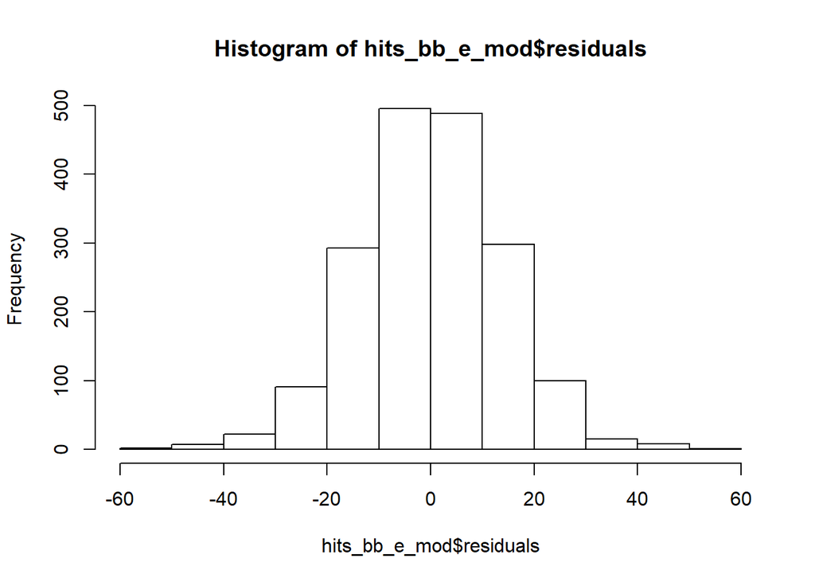

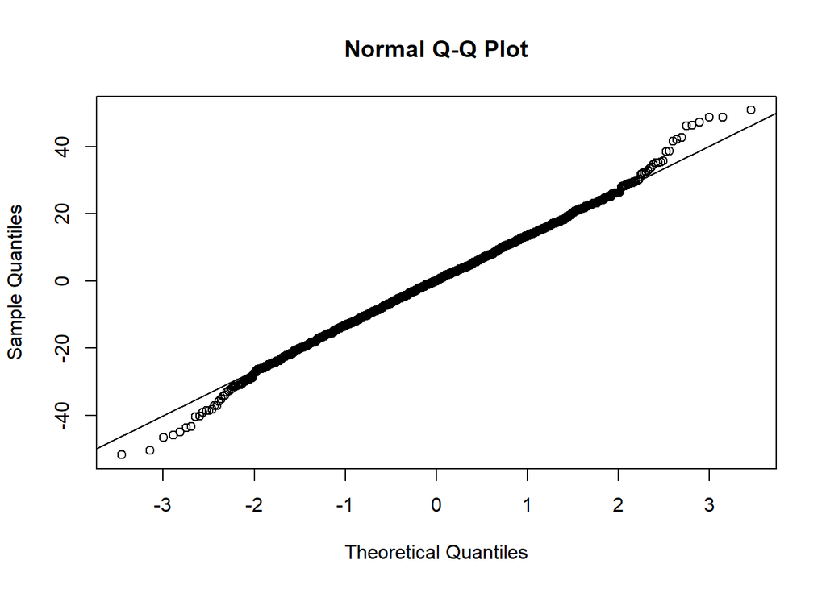

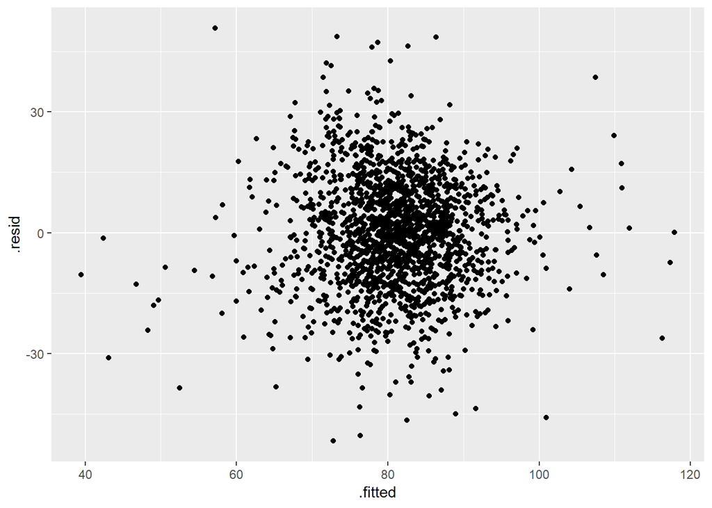

## 4.4 BoxCox Model

Attempt at boxcox, didn’t achieve better results in R squared (not SE not directly comparable due to adjustment with boxcox) The QQ plot seems to look a bit better as the negative quantiles are much closer to the line. Box Cox

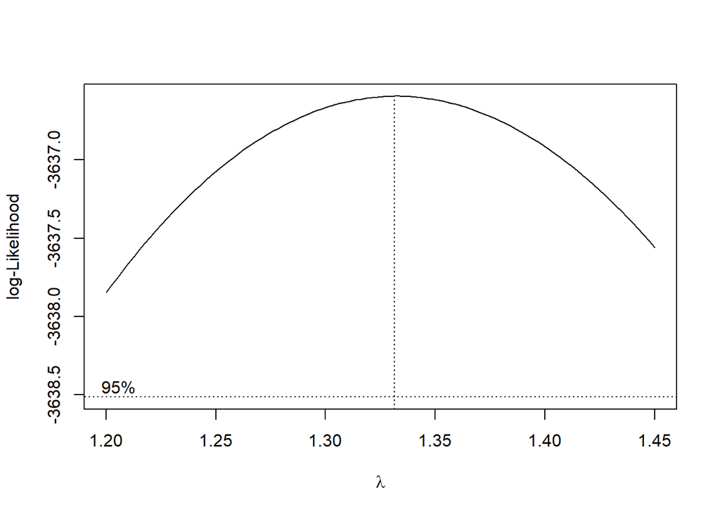

```
##
## Call:
## lm(formula = TARGET_WINS_BC ~ TEAM_BATTING_H + TEAM_BATTING_BB +
##     TEAM_FIELDING_E)
##
## Residuals:
##      Min       1Q   Median       3Q      Max
## -194.979  -38.736   -1.184   37.665  223.257
##
## Coefficients:
##                   Estimate Std. Error t value Pr(>|t|)
## (Intercept)     -64.017547  15.331986  -4.175 3.12e-05 ***
## TEAM_BATTING_H    0.211530   0.009709  21.787  < 2e-16 ***
## TEAM_BATTING_BB   0.053146   0.014776   3.597 0.000331 ***
## TEAM_FIELDING_E  -0.051346   0.008520  -6.026 2.03e-09 ***
## ---
## Signif. codes:  0 '***' 0.001 '**' 0.01 '*' 0.05 '.' 0.1 ' ' 1
##
## Residual standard error: 57.99 on 1816 degrees of freedom
## Multiple R-squared:  0.2317, Adjusted R-squared:  0.2305
## F-statistic: 182.6 on 3 and 1816 DF,  p-value: < 2.2e-16
```

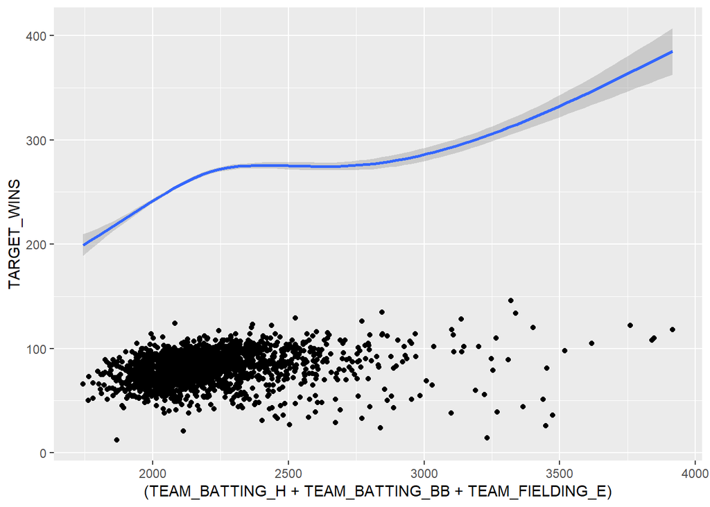

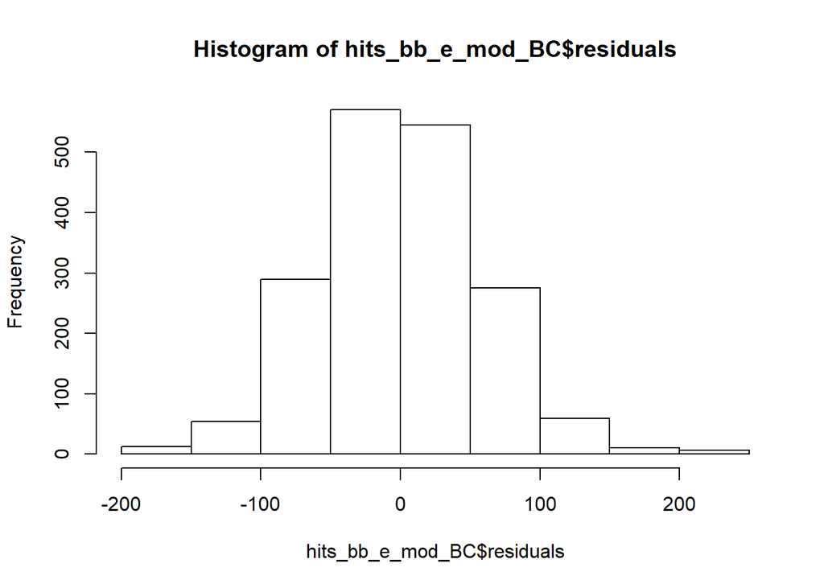

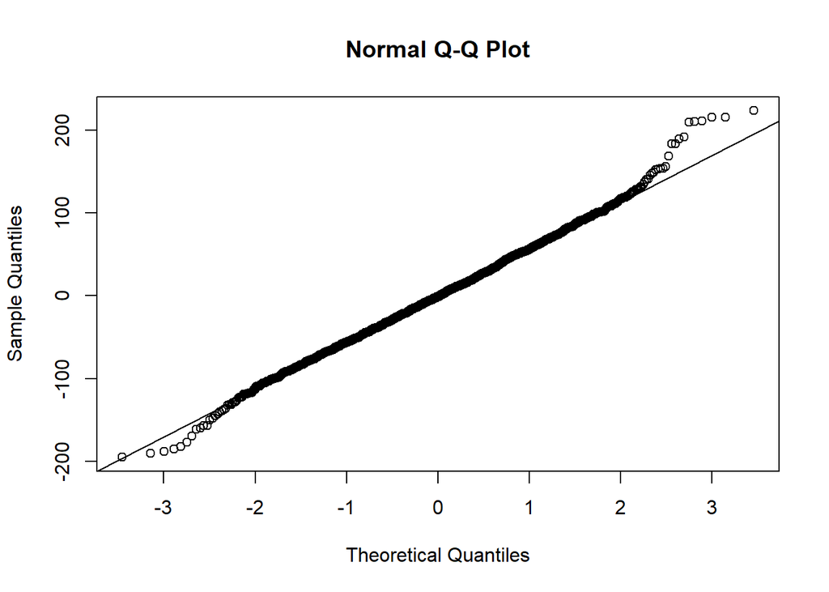

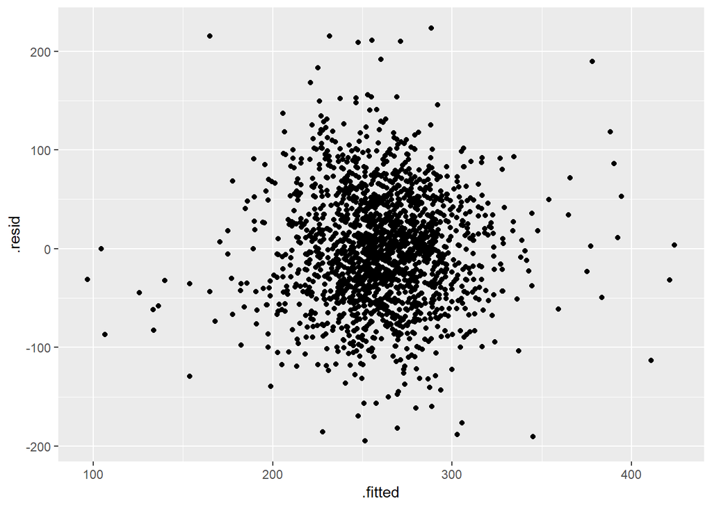

## 4.5 Run against Test DataSet

We developed models against the “Train” dataset (a random 80% from the entire training csv file), and now let’s run against the “test” dataset (being the other 20%). We see comparatively similar results in this cross validation of our models, with the model we picked originally (Hits without hr’s, BB’s, and errors) performing best.

Batting:

```
##
## Call:
## lm(formula = TARGET_WINS ~ TEAM_BATTING_H, data = test)
##
## Residuals:
##     Min      1Q  Median      3Q     Max
## -68.737  -8.935   1.556  10.264  38.579
##
## Coefficients:
##                 Estimate Std. Error t value Pr(>|t|)
## (Intercept)    24.386164   7.942929   3.070  0.00227 **
## TEAM_BATTING_H  0.038053   0.005391   7.059 6.32e-12 ***
## ---
## Signif. codes:  0 '***' 0.001 '**' 0.01 '*' 0.05 '.' 0.1 ' ' 1
##
## Residual standard error: 15 on 454 degrees of freedom
## Multiple R-squared:  0.0989, Adjusted R-squared:  0.09691
## F-statistic: 49.83 on 1 and 454 DF,  p-value: 6.324e-12
```

Pitching

```
##
## Call:
## lm(formula = TARGET_WINS ~ TEAM_PITCHING_H + TEAM_PITCHING_HR,
##     data = test)
##
## Residuals:
##     Min      1Q  Median      3Q     Max
## -79.667 -10.231   1.105  10.841  41.895
##
## Coefficients:
##                   Estimate Std. Error t value Pr(>|t|)
## (Intercept)      56.063991   5.616953   9.981  < 2e-16 ***
## TEAM_PITCHING_H   0.011492   0.003315   3.466 0.000578 ***
## TEAM_PITCHING_HR  0.057024   0.012299   4.636 4.65e-06 ***
## ---
## Signif. codes:  0 '***' 0.001 '**' 0.01 '*' 0.05 '.' 0.1 ' ' 1
##
## Residual standard error: 15.33 on 453 degrees of freedom
## Multiple R-squared:  0.06053,    Adjusted R-squared:  0.05638
## F-statistic: 14.59 on 2 and 453 DF,  p-value: 7.217e-07
```

Hits Without HomeRuns

```
##
## Call:
## lm(formula = TARGET_WINS ~ HITS_NOHR, data = test)
##
## Residuals:
##     Min      1Q  Median      3Q     Max
## -66.828  -9.885   2.126  10.988  36.153
##
## Coefficients:
##              Estimate Std. Error t value Pr(>|t|)
## (Intercept) 48.568743   6.916120   7.023 8.00e-12 ***
## HITS_NOHR    0.023172   0.005033   4.604 5.39e-06 ***
## ---
## Signif. codes:  0 '***' 0.001 '**' 0.01 '*' 0.05 '.' 0.1 ' ' 1
##
## Residual standard error: 15.44 on 454 degrees of freedom
## Multiple R-squared:  0.0446, Adjusted R-squared:  0.0425
## F-statistic:  21.2 on 1 and 454 DF,  p-value: 5.393e-06
```

Hits (no HR’s), BB, Errors:

```
##
## Call:
## lm(formula = TARGET_WINS ~ HITS_NOHR + TEAM_BATTING_BB + TEAM_FIELDING_E,
##     data = test)
##
## Residuals:
##     Min      1Q  Median      3Q     Max
## -37.312  -8.808  -0.024   9.322  43.261
##
## Coefficients:
##                  Estimate Std. Error t value Pr(>|t|)
## (Intercept)      8.462942   7.439747   1.138    0.256
## HITS_NOHR        0.042862   0.004644   9.229  < 2e-16 ***
## TEAM_BATTING_BB  0.036533   0.006750   5.412 1.01e-07 ***
## TEAM_FIELDING_E -0.021295   0.003304  -6.445 2.97e-10 ***
## ---
## Signif. codes:  0 '***' 0.001 '**' 0.01 '*' 0.05 '.' 0.1 ' ' 1
##
## Residual standard error: 13.32 on 452 degrees of freedom
## Multiple R-squared:  0.2921, Adjusted R-squared:  0.2874
## F-statistic: 62.16 on 3 and 452 DF,  p-value: < 2.2e-16
```

# 5 SELECT MODELS

## 5.1 Compare Model Statistics

| Metric | Batting Model | Pitching Model | Hits BB Errors Model | BoxCox Model |
| --- | --- | --- | --- | --- |
| RSE | 14.40 | 15.20 | 13.77 | 57.99 |
| R^2 | 0.1646 | 0.06883 | 0.237 | 0.2317 |
| Adj. R^2 | 0.1642 | 0.06781 | 0.2357 | 0.2305 |
| F Stat. | 358.2 | 67.16 | 188 | 182.6 |

When comparing models we can see how they all describe a rather small amount of the variation of the output data TARGET_WINS. Although all model calculated were statistically significant, showing small p-values for the F statistic, the majority of them showed R squared and adjusted R squared of less than 20%. This included models using the calculated variables added to the dataset. A BoxCox transformation was also performed in an attempt to generate a better model, but while its results of around 23% was higher than most models, at least one simpler model was found to have an equal R square of ~23%.

Important to note is the fact that the RSE for the transformation BoxCox model can’t really be used as a comparison with other models. this is because the underlaying variables have been changed or transformed in the process.

Residual plots were performed for all models and in general results were fairly similar and didn’t have as much effect in selecting a model, but were useful in validating models.

## 5.2 Pick the best regression model

The chosen regression model was the Batting and Fielding Errors Model. It was the model with the highest achieved R and adjusted R square. It was chosen over the BoxCox transformation model because it is a simpler model. A plot of predicted test data was plotted against real test data to understand how well the model performs. If the model were perfect, all point would fall on the plotted line, that is predicted and true values would be the same.

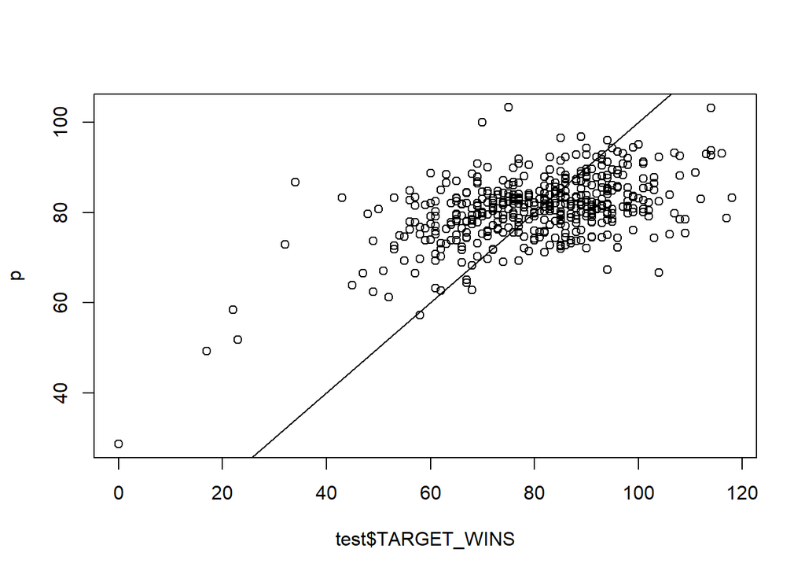

## 5.3 Conclusion

The model selected was generated using 80% of the training dataset. The remaining 20% was also used in cross validation to generate a similar model using the same predictor variables. Both models showed similar results, with the R square of the 20% data actually showing slightly higher. This is a good indication of lack of bias in the model, that is overfitting the model to the dataset given since a similar model was generated using different data.

Selected model was used to predict TARGET_WINS values from data in Evaluation data file, results were written to a csv file: predicted_eval_values.csv

# 6 APPENDIX

**Code used in analysis**

Find counts of na’s Notice that #hbp and cs (hit by pitch and caught stealing) have very large numbers of missing values, probably shouldn’t use, and knowing baseball, probably minor impact on wins regardless, so remove those columns…

```r
mbTrain <- read.csv("moneyball-training-data.csv")
sapply(mbTrain, function(x) sum(is.na(x)))
```

```
##            INDEX      TARGET_WINS   TEAM_BATTING_H  TEAM_BATTING_2B
##                0                0                0                0
##  TEAM_BATTING_3B  TEAM_BATTING_HR  TEAM_BATTING_BB  TEAM_BATTING_SO
##                0                0                0              102
##  TEAM_BASERUN_SB  TEAM_BASERUN_CS TEAM_BATTING_HBP  TEAM_PITCHING_H
##              131              772             2085                0
## TEAM_PITCHING_HR TEAM_PITCHING_BB TEAM_PITCHING_SO  TEAM_FIELDING_E
##                0                0              102                0
## TEAM_FIELDING_DP
##              286
```

```r
#remove those two columns, plus the index colume which we don't need
mbTrain <- mbTrain[, -which(names(mbTrain) %in% c("INDEX", "TEAM_BATTING_HBP", "TEAM_BASERUN_CS"))]
```

convert NA’s to -1 for now so we can run test on zero’s as zero’s for any of these stats clearly is inaccurate and eqivalent to an NA

Number of zeros fields is not so bad, but lets not replace them until we check for outliers and convert NA’s back to -1

```r
mbTrain[is.na(mbTrain)] <- -1
sapply(mbTrain, function(x) sum(x == 0))
```

```
##      TARGET_WINS   TEAM_BATTING_H  TEAM_BATTING_2B  TEAM_BATTING_3B
##                1                0                0                2
##  TEAM_BATTING_HR  TEAM_BATTING_BB  TEAM_BATTING_SO  TEAM_BASERUN_SB
##               15                1               20                2
##  TEAM_PITCHING_H TEAM_PITCHING_HR TEAM_PITCHING_BB TEAM_PITCHING_SO
##                0               15                1               20
##  TEAM_FIELDING_E TEAM_FIELDING_DP
##                0                0
```

Running summary we can see that there are some really big outliers (e.g., 19278 Strikeouts in one year?, that would be 119 per game….) at initial glance (can always revisit), looks like Pitching_Hits, Pitching_BB, Pitching_SO and Fielding Errors all have outliers that are not realistic values

```r
summary(mbTrain)
```

```
##   TARGET_WINS     TEAM_BATTING_H TEAM_BATTING_2B TEAM_BATTING_3B
##  Min.   :  0.00   Min.   : 891   Min.   : 69.0   Min.   :  0.00
##  1st Qu.: 71.00   1st Qu.:1383   1st Qu.:208.0   1st Qu.: 34.00
##  Median : 82.00   Median :1454   Median :238.0   Median : 47.00
##  Mean   : 80.79   Mean   :1469   Mean   :241.2   Mean   : 55.25
##  3rd Qu.: 92.00   3rd Qu.:1537   3rd Qu.:273.0   3rd Qu.: 72.00
##  Max.   :146.00   Max.   :2554   Max.   :458.0   Max.   :223.00
##  TEAM_BATTING_HR  TEAM_BATTING_BB TEAM_BATTING_SO  TEAM_BASERUN_SB
##  Min.   :  0.00   Min.   :  0.0   Min.   :  -1.0   Min.   : -1.0
##  1st Qu.: 42.00   1st Qu.:451.0   1st Qu.: 524.0   1st Qu.: 60.0
##  Median :102.00   Median :512.0   Median : 728.0   Median : 97.0
##  Mean   : 99.61   Mean   :501.6   Mean   : 702.6   Mean   :117.5
##  3rd Qu.:147.00   3rd Qu.:580.0   3rd Qu.: 925.0   3rd Qu.:151.0
##  Max.   :264.00   Max.   :878.0   Max.   :1399.0   Max.   :697.0
##  TEAM_PITCHING_H TEAM_PITCHING_HR TEAM_PITCHING_BB TEAM_PITCHING_SO
##  Min.   : 1137   Min.   :  0.0    Min.   :   0.0   Min.   :   -1.0
##  1st Qu.: 1419   1st Qu.: 50.0    1st Qu.: 476.0   1st Qu.:  587.8
##  Median : 1518   Median :107.0    Median : 536.5   Median :  797.0
##  Mean   : 1779   Mean   :105.7    Mean   : 553.0   Mean   :  781.0
##  3rd Qu.: 1682   3rd Qu.:150.0    3rd Qu.: 611.0   3rd Qu.:  957.0
##  Max.   :30132   Max.   :343.0    Max.   :3645.0   Max.   :19278.0
##  TEAM_FIELDING_E  TEAM_FIELDING_DP
##  Min.   :  65.0   Min.   : -1.0
##  1st Qu.: 127.0   1st Qu.:118.0
##  Median : 159.0   Median :145.0
##  Mean   : 246.5   Mean   :127.9
##  3rd Qu.: 249.2   3rd Qu.:161.2
##  Max.   :1898.0   Max.   :228.0
```

```r
#looking at top values we can see that there maybe a number of years that are unrealistic
head(sort(mbTrain$TEAM_PITCHING_H, decreasing = TRUE))
```

```
## [1] 30132 24057 20088 16871 16038 14749
```

```r
head(sort(mbTrain$TEAM_PITCHING_BB, decreasing = TRUE))
```

```
## [1] 3645 2876 2840 2396 2169 1750
```

```r
head(sort(mbTrain$TEAM_PITCHING_SO, decreasing = TRUE))
```

```
## [1] 19278 12758  5456  4224  3450  2492
```

```r
head(sort(mbTrain$TEAM_FIELDING_E, decreasing = TRUE))
```

```
## [1] 1898 1890 1740 1728 1567 1553
```

Let’s plot to see where outliers are

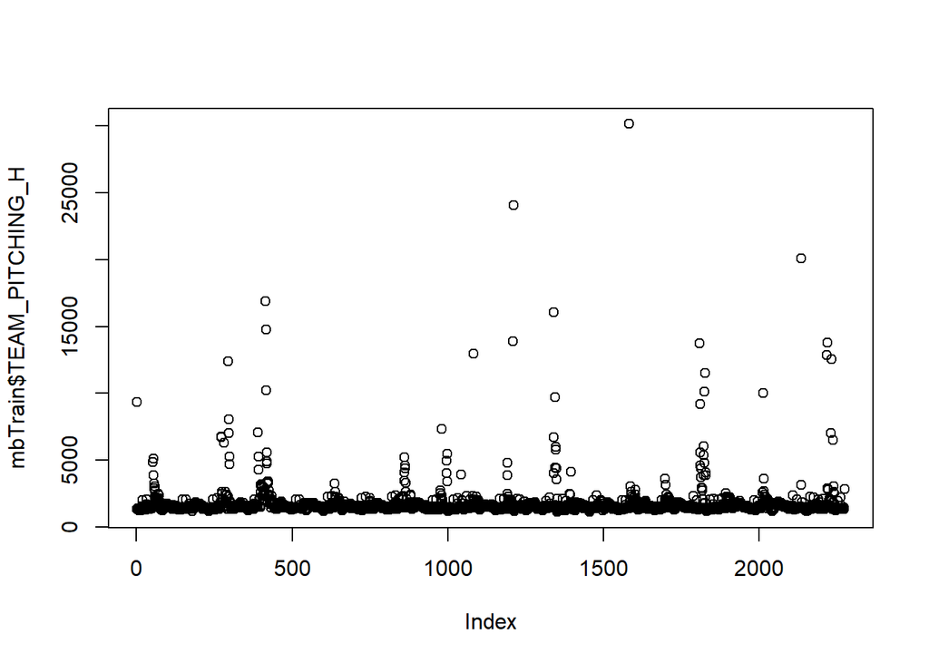

```r
plot(mbTrain$TEAM_PITCHING_H)
```

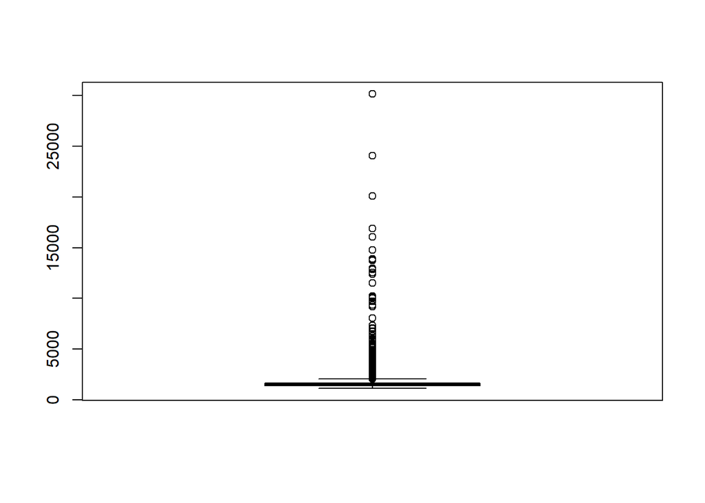

```r
boxplot(mbTrain$TEAM_PITCHING_H)
```

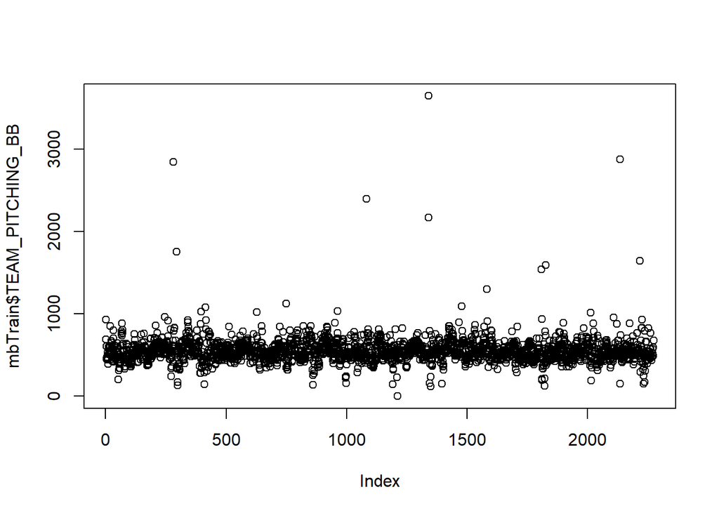

```r
plot(mbTrain$TEAM_PITCHING_BB)
```

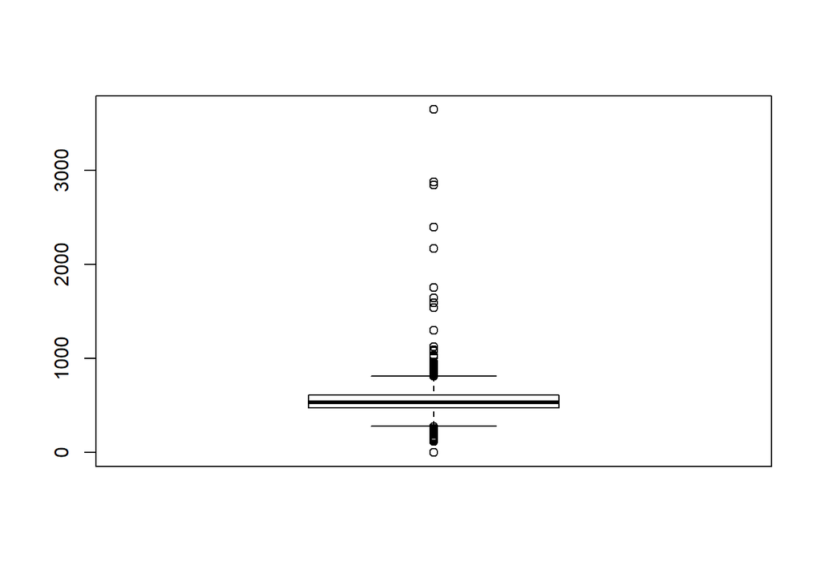

```r
boxplot(mbTrain$TEAM_PITCHING_BB)
```

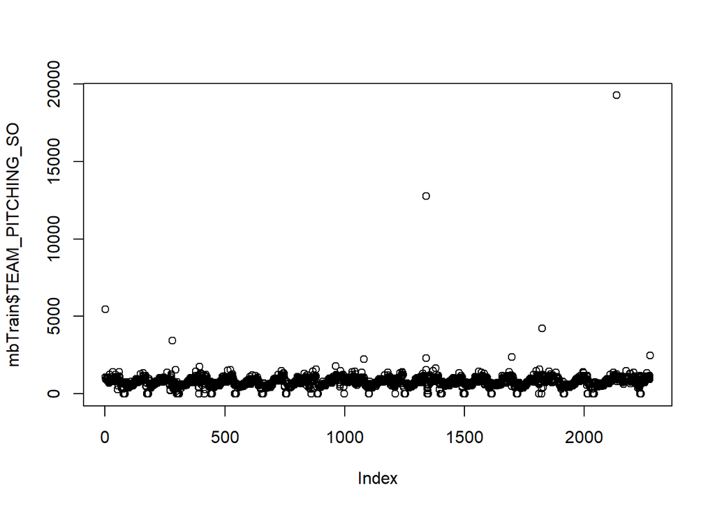

```r
plot(mbTrain$TEAM_PITCHING_SO)
```

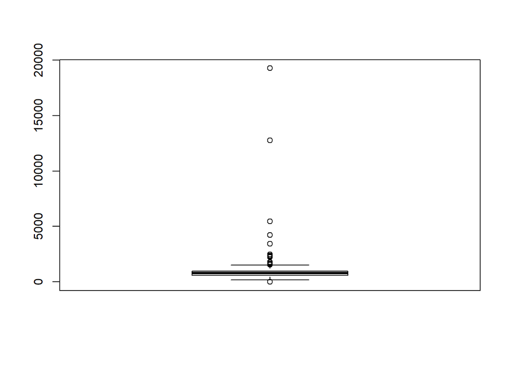

```r
boxplot(mbTrain$TEAM_PITCHING_SO)
```

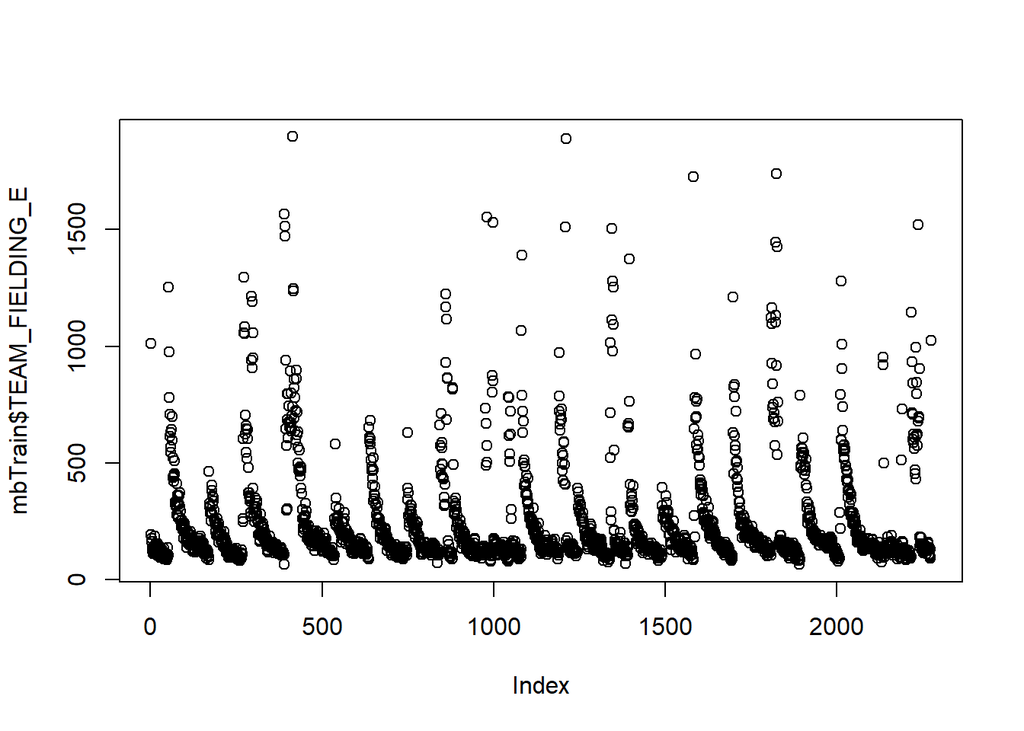

```r
plot(mbTrain$TEAM_FIELDING_E)
```

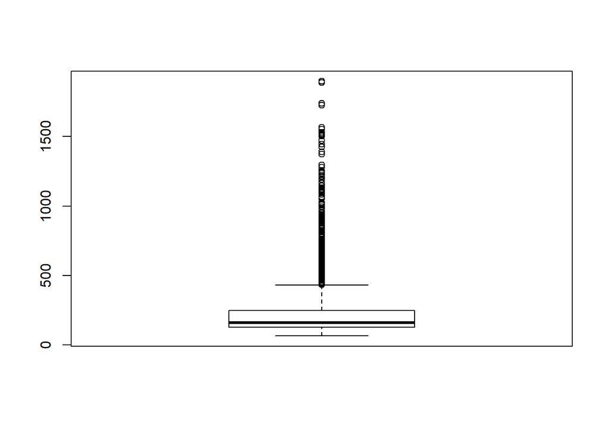

```r
boxplot(mbTrain$TEAM_FIELDING_E)
```

There are a lot of rows with pitching hits greater than 3000 (there was max of 2554 hits by batting team, so a limit of 3000 hits (18.5 avg per game) by a pitching team doesn’t seem so unreasonable as max)we see 86, these should probably be tossed and replaced with median (mean?)

```r
sum(mbTrain$TEAM_PITCHING_H > 3000)
```

```
## [1] 86
```

Using same idea for base on balls, max for batting was 878, so perhaps a 1200 max for pitching (7.5 avg a game) might be reasonable, so 10 rows like this.

```r
sum(mbTrain$TEAM_PITCHING_BB > 1200)
```

```
## [1] 10
```

for strikeouts, batting max of 1399, so perhaps 1800 for pitching max, and we have 9 rows like this.

```
## [1] 9
```

For fielding errors, there is no corresponding number to validate against (like with pitching compared to batting), but if we use a plausible limit of about 10 per game (which is still really high we can eliminate clear outliers).

```
## [1] 4
```

```r
mbTrain$TEAM_PITCHING_H[mbTrain$TEAM_PITCHING_H>max(mbTrain$TEAM_BATTING_H)] <- median(mbTrain$TEAM_PITCHING_H, na.rm=TRUE)
mbTrain$TEAM_PITCHING_SO[mbTrain$TEAM_PITCHING_SO>max(mbTrain$TEAM_BATTING_SO)] <- median(mbTrain$TEAM_PITCHING_SO, na.rm=TRUE)
```

Do some correlation

```
##      TEAM_BATTING_H TEAM_BATTING_2B TEAM_BATTING_3B TEAM_BATTING_HR
## [1,]      0.3887675       0.2891036       0.1426084       0.1761532
##      TEAM_BATTING_BB TEAM_BATTING_SO TEAM_BASERUN_SB TEAM_PITCHING_H
## [1,]       0.2325599     -0.03009449       0.1207944       0.1808751
##      TEAM_PITCHING_HR TEAM_PITCHING_BB TEAM_PITCHING_SO TEAM_FIELDING_E
## [1,]        0.1890137        0.1241745      -0.05078415      -0.1764848
##      TEAM_FIELDING_DP
## [1,]       0.01904895
```

Do some basic plots to start looking at data:

```r
attach(mbTrain)
```

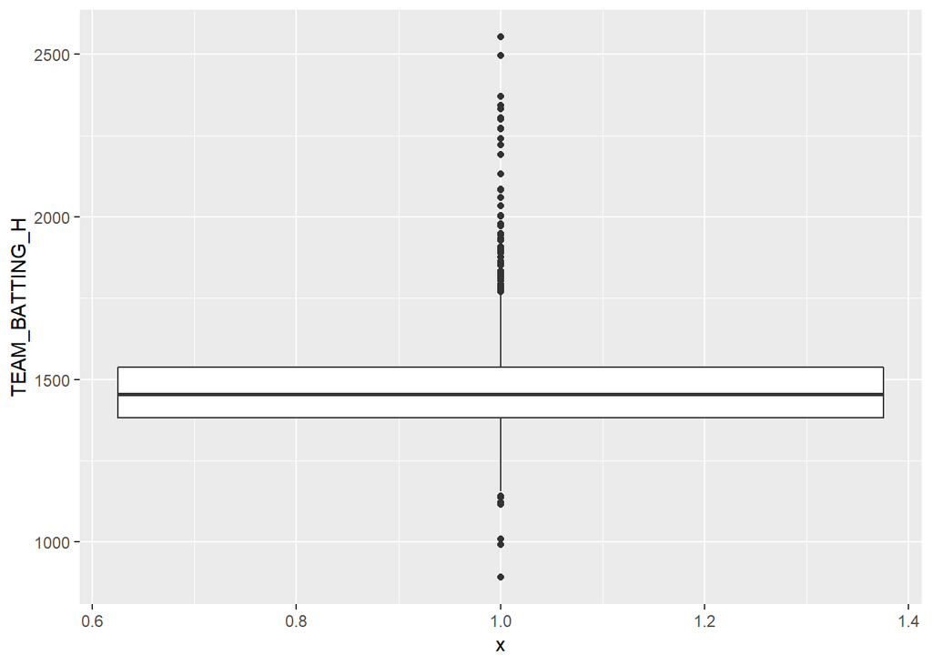

```r
ggplot(mbTrain, aes(y=TEAM_BATTING_H, x= 1)) + geom_boxplot()
```

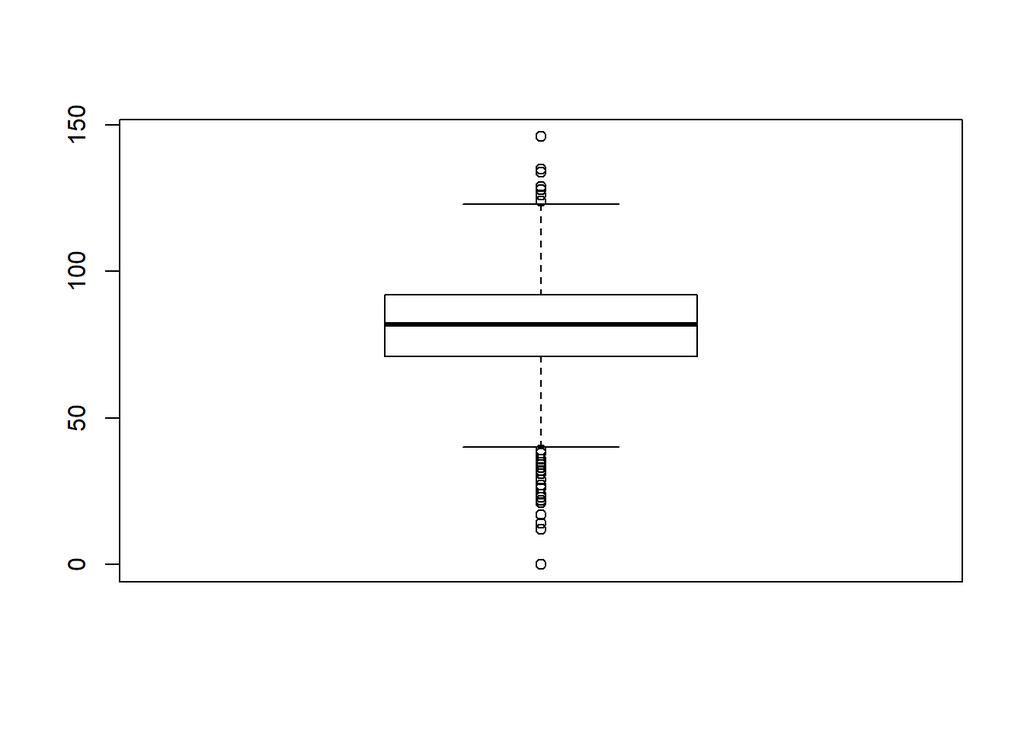

```r
boxplot(TARGET_WINS)
```

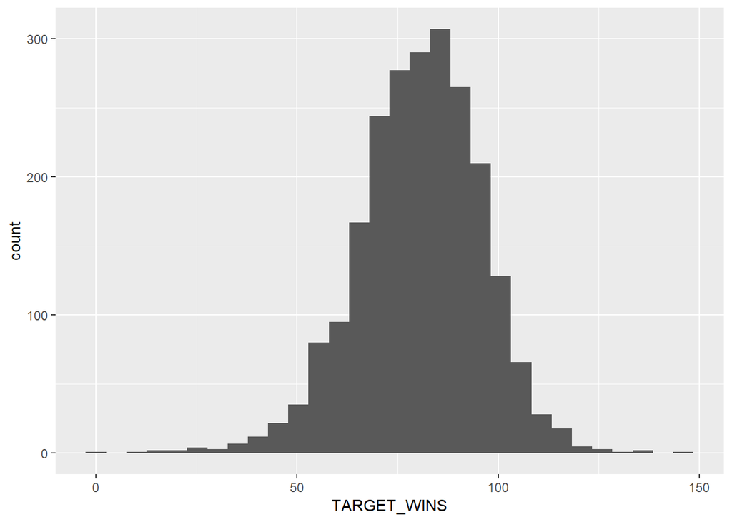

```r
#note appears reasonably normally distributed
ggplot() + geom_histogram(aes(x = TARGET_WINS))
```

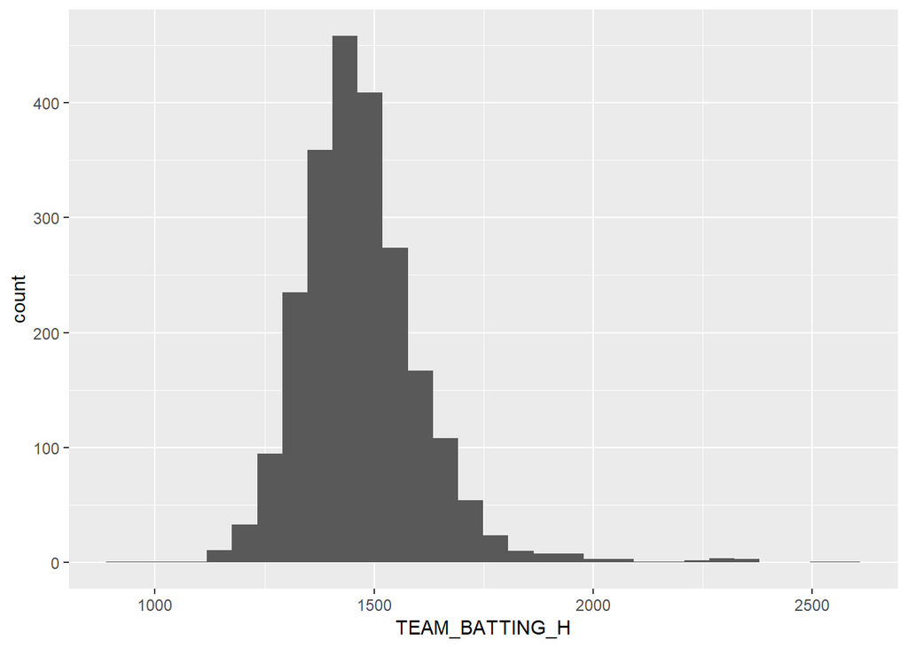

```r
ggplot() + geom_histogram(aes(x = TEAM_BATTING_H))
```

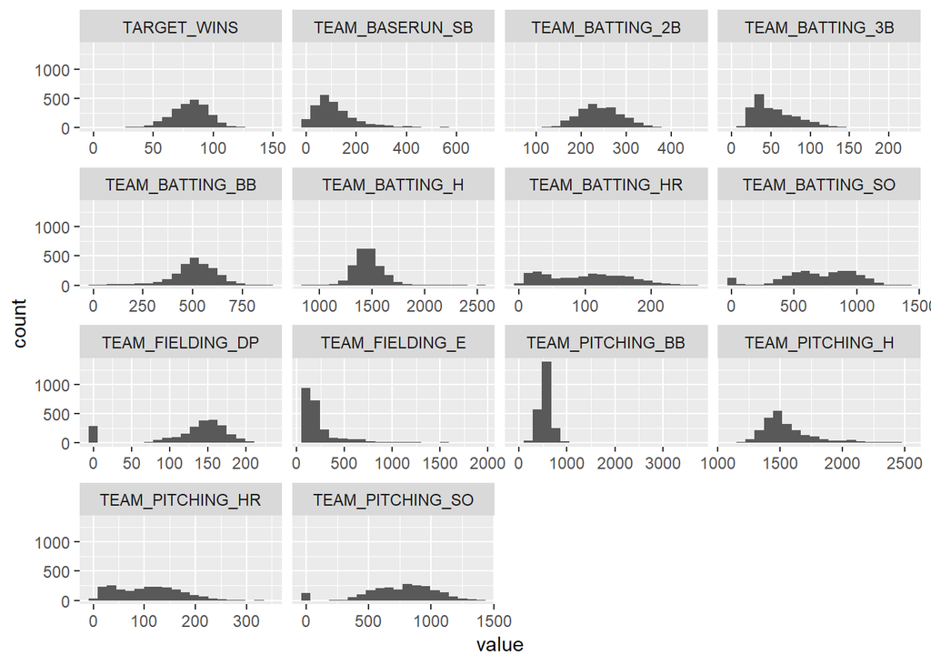

```r
ggplot(gather(mbTrain), aes(value)) +
    geom_histogram(bins = 20) +
    facet_wrap(~key, scales = "free_x")
```

Fit a couple really simple models just to explore, one with everything, one with just home runs against wins.

```r
lmFit <- lm(TARGET_WINS ~., data = mbTrain)
summary(lmFit)
```

```
##
## Call:
## lm(formula = TARGET_WINS ~ ., data = mbTrain)
##
## Residuals:
##     Min      1Q  Median      3Q     Max
## -60.173  -8.324   0.168   8.670  51.804
##
## Coefficients:
##                   Estimate Std. Error t value Pr(>|t|)
## (Intercept)      37.397579   4.732471   7.902 4.24e-15 ***
## TEAM_BATTING_H    0.044540   0.003455  12.890  < 2e-16 ***
## TEAM_BATTING_2B  -0.006759   0.009279  -0.728 0.466427
## TEAM_BATTING_3B   0.078149   0.016958   4.608 4.29e-06 ***
## TEAM_BATTING_HR   0.072884   0.028139   2.590 0.009656 **
## TEAM_BATTING_BB   0.004194   0.004366   0.961 0.336758
## TEAM_BATTING_SO  -0.022270   0.003805  -5.853 5.54e-09 ***
## TEAM_BASERUN_SB   0.002304   0.004127   0.558 0.576626
## TEAM_PITCHING_H  -0.006469   0.001765  -3.665 0.000253 ***
## TEAM_PITCHING_HR -0.011394   0.024897  -0.458 0.647261
## TEAM_PITCHING_BB  0.004409   0.002462   1.791 0.073500 .
## TEAM_PITCHING_SO  0.013304   0.003213   4.141 3.58e-05 ***
## TEAM_FIELDING_E  -0.036860   0.002788 -13.223  < 2e-16 ***
## TEAM_FIELDING_DP -0.084309   0.010084  -8.360  < 2e-16 ***
## ---
## Signif. codes:  0 '***' 0.001 '**' 0.01 '*' 0.05 '.' 0.1 ' ' 1
##
## Residual standard error: 13.21 on 2262 degrees of freedom
## Multiple R-squared:  0.3012, Adjusted R-squared:  0.2971
## F-statistic: 74.98 on 13 and 2262 DF,  p-value: < 2.2e-16
```

```r
lmFit <- lm(TARGET_WINS ~ TEAM_BATTING_HR, data = mbTrain)
summary(lmFit)
```

```
##
## Call:
## lm(formula = TARGET_WINS ~ TEAM_BATTING_HR, data = mbTrain)
##
## Residuals:
##     Min      1Q  Median      3Q     Max
## -76.226  -9.909   0.520  10.218  68.445
##
## Coefficients:
##                 Estimate Std. Error t value Pr(>|t|)
## (Intercept)     76.22576    0.62599 121.768   <2e-16 ***
## TEAM_BATTING_HR  0.04583    0.00537   8.534   <2e-16 ***
## ---
## Signif. codes:  0 '***' 0.001 '**' 0.01 '*' 0.05 '.' 0.1 ' ' 1
##
## Residual standard error: 15.51 on 2274 degrees of freedom
## Multiple R-squared:  0.03103,    Adjusted R-squared:  0.0306
## F-statistic: 72.82 on 1 and 2274 DF,  p-value: < 2.2e-16
```

Let’s plot hits against wins as that field should highest correlation.

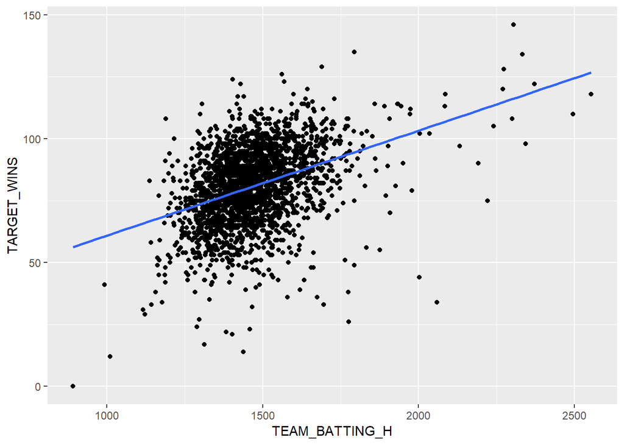

```r
lmFitH <- lm(TARGET_WINS ~ TEAM_BATTING_H)
ggplot(mbTrain, aes(x= TEAM_BATTING_H, y = TARGET_WINS)) +
    geom_point() +
    geom_smooth(method = "lm", se= FALSE)
```

Plot Residuals

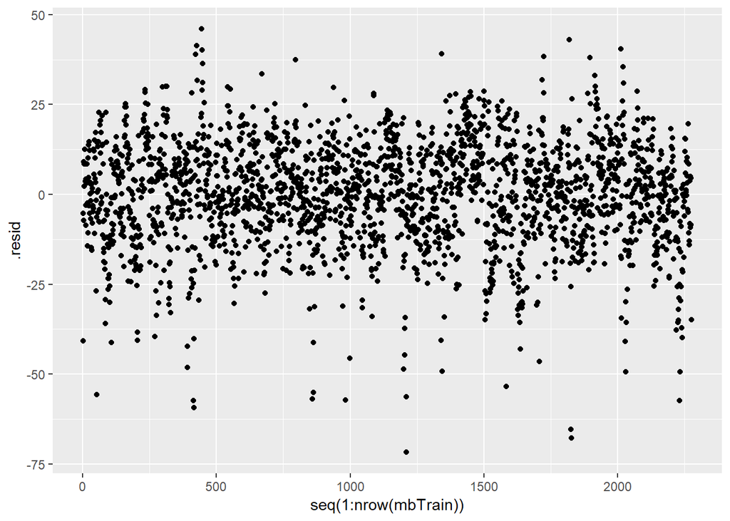

```r
#vs index
ggplot(lmFitH, aes(x= seq(1:nrow(mbTrain)), y= .resid)) +geom_point()
```

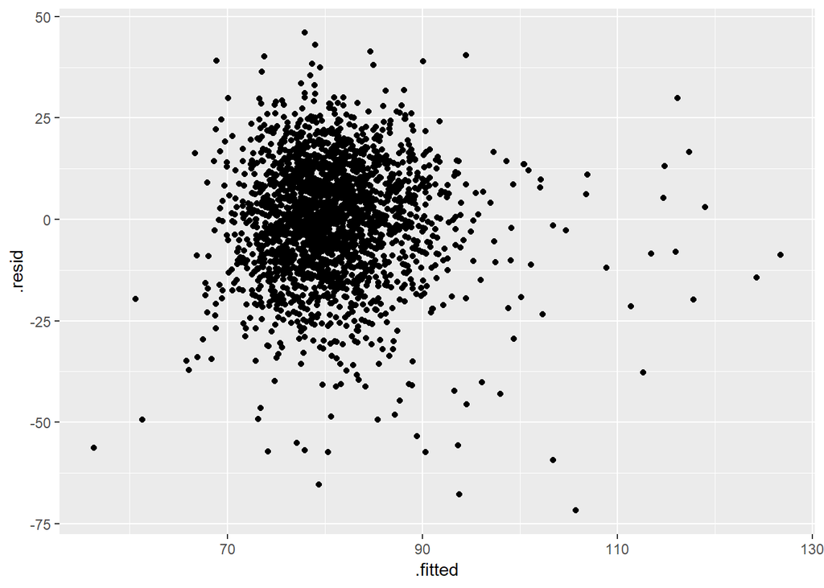

```r
#vs fitted value
ggplot(lmFitH, aes(x= .fitted, y= .resid)) +geom_point()
```